# Data Load

```python
import pandas as pd
Riskdata = pd.read_csv("https://storage.googleapis.com/datalynn-datasets/interview-challenge/technology/Paypal_Risk_Management/Riskdata.csv")
```

# Question 1

Historical Data Analysis: Given the UserRiskProfile table, can you identify patterns or anomalies in the TransactionHist over the last six months that might correlate with users who have a history of chargebacks (ChargebackHist)?

## Solution:

### Hints:

- Feature Engineering: Create new features that could provide more insight, such as average transaction amounts, transaction frequency, or the standard deviation of transaction amounts over time.
- Correlation Analysis: As you've already considered, calculating correlations can help quickly identify any linear relationships. You may also consider Spearman rank correlation for non-linear relationships.
- Visual Inspection: Sometimes patterns can be easily spotted through data visualization. Consider plotting transaction histories against chargebacks over time for individual or groups of users.

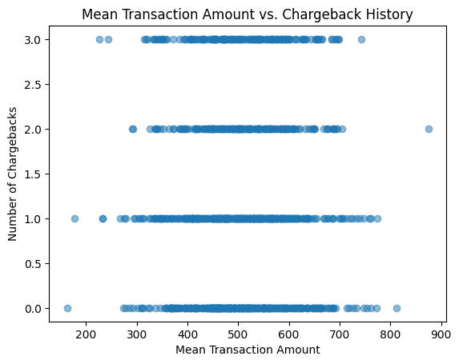

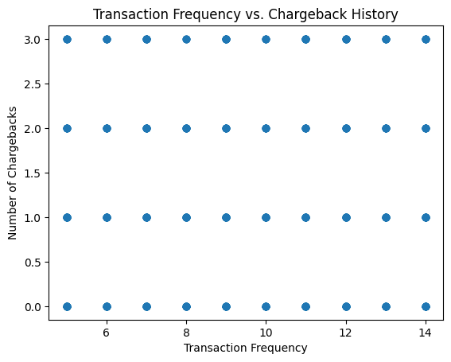

```
                       MeanTransactionAmount  TransactionFrequency  \
MeanTransactionAmount               1.000000             -0.039541
TransactionFrequency               -0.039541              1.000000
ChargebackHist                      0.012751              0.047244

                       ChargebackHist
MeanTransactionAmount        0.012751
TransactionFrequency         0.047244
ChargebackHist               1.000000
```

```python
import pandas as pd
import numpy as np
import matplotlib.pyplot as plt

# Load data from CSV
df_UserRiskProfile = pd.read_csv("https://storage.googleapis.com/datalynn-datasets/interview-challenge/technology/Paypal_Risk_Management/Riskdata.csv")

# Custom function to convert string to list
def str_to_list(s):
    if isinstance(s, str):
        return list(map(int, s[1:-1].split()))
    return s

# Convert string representation to list
df_UserRiskProfile['TransactionHist'] = df_UserRiskProfile['TransactionHist'].apply(str_to_list)

# Handle cases where TransactionHist is empty or None
def safe_mean(lst):
    return np.mean(lst) if lst else 0

def safe_len(lst):
    return len(lst) if lst else 0

# Generate a new feature: Average Transaction Amount for each user
df_UserRiskProfile['MeanTransactionAmount'] = df_UserRiskProfile['TransactionHist'].apply(safe_mean)

# Generate a new feature: Transaction Frequency for each user
df_UserRiskProfile['TransactionFrequency'] = df_UserRiskProfile['TransactionHist'].apply(safe_len)

# Plot Mean Transaction Amount vs. Chargeback History
plt.figure()
plt.title("Mean Transaction Amount vs. Chargeback History")
plt.scatter(df_UserRiskProfile['MeanTransactionAmount'], df_UserRiskProfile['ChargebackHist'], alpha=0.5)
plt.xlabel('Mean Transaction Amount')
plt.ylabel('Number of Chargebacks')
plt.show()

# Plot Transaction Frequency vs. Chargeback History
plt.figure()
plt.title("Transaction Frequency vs. Chargeback History")
plt.scatter(df_UserRiskProfile['TransactionFrequency'], df_UserRiskProfile['ChargebackHist'], alpha=0.5)
plt.xlabel('Transaction Frequency')
plt.ylabel('Number of Chargebacks')
plt.show()

# Compute the correlation matrix
correlation_matrix = df_UserRiskProfile[['MeanTransactionAmount', 'TransactionFrequency', 'ChargebackHist']].corr()

# Print the correlation matrix
print(correlation_matrix)
```

Conclusion: Based on the correlation analysis, there is no strong evidence to suggest that either the average transaction amount (`MeanTransactionAmount`) or the frequency of transactions (`TransactionFrequency`) are closely related to the history of chargebacks (`ChargebackHist`). Both variables have near-zero correlation values with `ChargebackHist`, implying that they are not good predictors for assessing the risk of chargebacks. This indicates that other factors, not captured in the analyzed features, might be influencing the occurrence of chargebacks, and further investigation is warranted.

# Question 2

Loan Default Prediction: Based on the data provided in UserRiskProfile, build a model to predict the LoanDefaulted target variable.

*Which features were the most influential in your model's prediction? How would you handle TransactionHist as it's a time series feature in this context?*

## Solution:

### Hints:

- Feature Selection: Start by evaluating the data to identify the most critical features. Features like credit score, loan amount, and chargeback history are often good indicators of loan default risks.
- Handling Time-Series Data: The TransactionHist field is a time-series, and machine learning models like Random Forest can't directly handle this. You might want to engineer features like 'average transaction amount,' 'number of transactions,' or even 'rate of change of transactions' to capture the essence of the transaction history.

```python
from sklearn.ensemble import RandomForestClassifier
from sklearn.model_selection import train_test_split
from sklearn.metrics import classification_report
import numpy as np

# Feature engineering for TransactionHist
# For simplicity, let's calculate the mean and standard deviation of past transactions for each user
df_UserRiskProfile['MeanTransactionAmount'] = df_UserRiskProfile['TransactionHist'].apply(np.mean)
df_UserRiskProfile['StdTransactionAmount'] = df_UserRiskProfile['TransactionHist'].apply(np.std)

# Prepare features and target variable
X = df_UserRiskProfile[['CreditScore', 'MeanTransactionAmount', 'StdTransactionAmount', 'LoanOffered', 'FeedbackScore', 'ChargebackHist', 'MerchantRating', 'ThirdPartyData']]
y = df_UserRiskProfile['LoanDefaulted']

# Train-test split
X_train, X_test, y_train, y_test = train_test_split(X, y, test_size=0.3, random_state=42)

# Model training
clf = RandomForestClassifier(random_state=42)
clf.fit(X_train, y_train)

# Prediction and evaluation
y_pred = clf.predict(X_test)
print("Classification Report:\n", classification_report(y_test, y_pred))

# Feature Importances
print("Feature importances:", clf.feature_importances_)
```

```
Classification Report:
               precision    recall  f1-score   support

           0       0.79      0.91      0.84        95
           1       0.95      0.89      0.92       205

    accuracy                           0.89       300
   macro avg       0.87      0.90      0.88       300
weighted avg       0.90      0.89      0.90       300

Feature importances: [0.37301801 0.07666158 0.07347499 0.08599761 0.02617183 0.0508965
 0.02537849 0.28840099]
```

Conclusion: The Random Forest model achieved an overall accuracy of 89%, showing a high degree of robustness in predicting loan defaults. The most influential features were `CreditScore` (37.3%) and `ThirdPartyData` (28.8%), indicating their critical role in risk assessment. Features like `FeedbackScore` and `MerchantRating` had minimal impact, suggesting they may not be essential for the model. The results indicate that focusing on improving data around `CreditScore` and `ThirdPartyData` could further enhance the model's predictive capability.

# Question 3

Product Recommendation: Considering that PayPal might want to introduce new financial products or adjustments to existing offerings, use the UserRiskProfile data to segment users. Can you suggest targeted product offerings or policies for each segment based on their risk profile? For instance, users with a certain CreditScore range might benefit from a different loan offering.

## Solution:

### Hints:

- Feature Selection: Carefully choose the variables that capture various aspects of the user's financial behavior and risk profile. It's essential to pick features that are likely to distinguish different user clusters effectively.
- Data Preprocessing: Ensure that the data is normalized or standardized, as K-means clustering is sensitive to the scale of data.
- Number of Clusters: The choice of the number of clusters (n_clusters in KMeans) can significantly impact the segmentation. You can use techniques like the Elbow Method to determine the optimal number of clusters.
- Product Matching: After identifying the clusters, think from a business perspective to match the identified user needs with suitable products. It's not just about the technical accuracy of clusters but also about how actionable they are.

```python
from sklearn.cluster import KMeans
from sklearn.preprocessing import StandardScaler
from sklearn.metrics import silhouette_score

# Calculate the mean transaction amount for each user and add it as a feature
df_UserRiskProfile['MeanTransactionAmount'] = df_UserRiskProfile['TransactionHist'].apply(lambda x: np.mean(x))

# Drop non-numeric and target variables for clustering
X = df_UserRiskProfile.drop(['UserID', 'TransactionHist', 'TransactionDate', 'LoanDefaulted'], axis=1)

# Normalize features
scaler = StandardScaler()
X_scaled = scaler.fit_transform(X)

# Initialize and fit KMeans
best_n_clusters = 3  # Use silhouette score or elbow method to find the best number of clusters
kmeans = KMeans(n_clusters=best_n_clusters, n_init=10)
kmeans.fit(X_scaled)

# Add cluster labels to the original dataframe
df_UserRiskProfile['Cluster'] = kmeans.labels_

# Display mean values for each cluster
# Explicitly specify numeric_only to suppress warning
cluster_summary = df_UserRiskProfile.groupby('Cluster').mean(numeric_only=True)
print(cluster_summary)

# Calculate silhouette score
print("Silhouette Score:", silhouette_score(X_scaled, kmeans.labels_))
```

```
         Unnamed: 0      UserID  CreditScore  LoanOffered  FeedbackScore  \
Cluster
0        494.255452  495.255452   517.688474   283.825545       1.813084
1        508.985507  509.985507   580.963768   467.241546       4.202899
2        491.033962  492.033962   596.981132   687.920755       2.139623

         ChargebackHist  MerchantRating  ThirdPartyData  LoanDefaulted  \
Cluster
0              1.445483        2.087227       33.264798       0.822430
1              0.512077        4.371981       48.753623       0.652174
2              1.913208        2.509434       71.237736       0.600000

         MeanTransactionAmount  TransactionFrequency  StdTransactionAmount
Cluster
0                   505.727957              8.993769            267.885400
1                   498.642416              9.649758            266.817659
2                   520.244263              9.471698            261.941041
Silhouette Score: 0.12033311988191082
```

- Suggested Products: High-value loans, reward programs, and fraud protection services.

- Suggested Products: Credit building tools, small short-term loans, and stringent fraud checks.

- Suggested Products: Premium credit cards, investment products, and loyalty programs.

# Question 4

Risk Evaluation through External Data: Often, ThirdPartyData might have a different scale or might be evaluated differently than CreditScore. Design a strategy to normalize these features and determine how much weightage should be given to internal (CreditScore) vs external (ThirdPartyData) scores when evaluating user risk. Implement this and identify users that might have been perceived as high-risk by PayPal's internal data but are considered low-risk by external data and vice versa.

## Solution:

### Hints:

- Data Normalization: Utilize techniques like MinMax scaling, Z-score normalization, etc., to make sure the CreditScore and ThirdPartyData are on the same scale.
- Weightage Exploration: Start with equal weights for internal and external scores. Experiment by varying these weights and observe how it affects your risk evaluation.
- Method Validation: Split your data into a training and test set to validate the efficacy of your risk evaluation method.

```python
from sklearn.preprocessing import MinMaxScaler

# Normalize
scaler = MinMaxScaler()
df_UserRiskProfile[['CreditScore', 'ThirdPartyData']] = scaler.fit_transform(df_UserRiskProfile[['CreditScore', 'ThirdPartyData']])

# Weighted Risk Score
df_UserRiskProfile['WeightedRiskScore'] = 0.6 * df_UserRiskProfile['CreditScore'] + 0.4 * df_UserRiskProfile['ThirdPartyData']

# Find users with different risk assessments between CreditScore and ThirdPartyData
df_high_risk_internal_low_risk_external = df_UserRiskProfile[(df_UserRiskProfile['CreditScore'] > 0.7) & (df_UserRiskProfile['ThirdPartyData'] <= 0.4)]
df_low_risk_internal_high_risk_external = df_UserRiskProfile[(df_UserRiskProfile['CreditScore'] <= 0.4) & (df_UserRiskProfile['ThirdPartyData'] > 0.7)]

# Show just the first 5 rows for these users
print("High risk by internal, but low risk by external data:\n", df_high_risk_internal_low_risk_external.head())
print("\nLow risk by internal, but high risk by external data:\n", df_low_risk_internal_high_risk_external.head())
```

```
High risk by internal, but low risk by external data:
     Unnamed: 0  UserID  CreditScore  \
7            7       8     0.847273
23          23      24     0.834545
27          27      28     0.861818
47          47      48     0.825455
48          48      49     0.776364

                                      TransactionHist  LoanOffered  \
7   [17, 641, 217, 61, 939, 616, 42, 25, 39, 803, ...          476
23  [964, 140, 187, 805, 61, 997, 939, 380, 710, 8...          854
27          [54, 47, 727, 689, 521, 99, 20, 890, 753]          223
47                 [849, 382, 748, 440, 604, 989, 21]          450
48       [955, 84, 774, 659, 953, 453, 387, 507, 257]          198

```

[output cut: 56 more lines]

The results suggest that both internal and external risk metrics have their merits and pitfalls, and a balanced approach might be the best way forward for PayPal's risk management.